# Beetle population dynamics: predictors selection (tmp, tmp_z, spei12)

Maria Potterf

2024-10-04

# 1 Motivation & goal

- when using the previous years values of beetle population, the effect of tmp can be already accounted for. Therefore, should use curent year tmp/tmp_z. what SPEI lag is the better to use?
- tested SPEI12_lag0, SPEI12_lag1,SPEI12_lag2 > SPEI12_lag1 has the most interpretable results
- rerun the models with current year temperature (_lag0) and previous year SPEI12 (_lag1).
- test if tmp_z or tmp is performing better? in combination ‘tmp_z + spei’ vs ‘tmp + spei’
- create individual models and compare their performance:

Dependent vars:

- SUM_IPS
- AGG_DOY
- PEAK_DOY
- PEAK_DIFF

Predictors

- SPEI12 (lag1)
- tmp (lag0)
- tmp_z (lag0)

```
## [1] "C:/Users/ge45lep/Documents/2022_BarkBeetles_Bavaria/r_beetlesbavaria"
```

```r
library(ggplot2)
library(ggeffects)
library(ggpubr)
library(MuMIn)
library(gratia)
```

# 2 Results

## 2.1 Find best SPEI LAG

### 2.1.1 Summary tmp_z spei12_lag0

```r
summary(m.previous.tmp_z0_spei12_0$gam)
```

```
##
## Family: Tweedie
## Link function: log
##
## Formula:
## sum_ips ~ s(tmp_z_lag0, k = 5) + s(spei12_lag0, k = 8) + te(tmp_z_lag0,
##     spei12_lag0, k = 7) + s(sum_ips_lag1, k = 5) + s(x, y)
##
## Parametric coefficients:
##             Estimate Std. Error t value Pr(>|t|)
## (Intercept) 10.09162    0.02088   483.3   <2e-16 ***
## ---
## Signif. codes:  0 '***' 0.001 '**' 0.01 '*' 0.05 '.' 0.1 ' ' 1
##
## Approximate significance of smooth terms:
##                               edf Ref.df      F p-value
## s(tmp_z_lag0)               1.000  1.000  0.833 0.36191
## s(spei12_lag0)              3.946  3.946  2.793 0.02761 *
## te(tmp_z_lag0,spei12_lag0)  3.502  3.502  2.661 0.02259 *
## s(sum_ips_lag1)             2.578  2.578 57.321 < 2e-16 ***
## s(x,y)                     11.313 11.313  2.359 0.00851 **
## ---
## Signif. codes:  0 '***' 0.001 '**' 0.01 '*' 0.05 '.' 0.1 ' ' 1
##
## R-sq.(adj) =  0.433
##   Scale est. = 29.68     n = 444
```

### 2.1.2 Summary tmp_z spei12_lag1

```r
summary(m.previous.tmp_z0_spei12_1$gam)
```

```
##
## Family: Tweedie
## Link function: log
##
## Formula:
## sum_ips ~ s(tmp_z_lag0, k = 5) + s(spei12_lag1, k = 8) + te(tmp_z_lag0,
##     spei12_lag1, k = 7) + s(sum_ips_lag1, k = 5) + s(x, y)
##
## Parametric coefficients:
##             Estimate Std. Error t value Pr(>|t|)
## (Intercept) 10.09076    0.02028   497.6   <2e-16 ***
## ---
## Signif. codes:  0 '***' 0.001 '**' 0.01 '*' 0.05 '.' 0.1 ' ' 1
##
## Approximate significance of smooth terms:
##                               edf Ref.df      F  p-value
## s(tmp_z_lag0)               1.000  1.000  1.807   0.1796
## s(spei12_lag1)              1.000  1.000  0.146   0.7030
## te(tmp_z_lag0,spei12_lag1)  8.057  8.057  4.787 1.19e-05 ***
## s(sum_ips_lag1)             2.593  2.593 59.326  < 2e-16 ***
## s(x,y)                     10.975 10.975  1.808   0.0575 .
## ---
## Signif. codes:  0 '***' 0.001 '**' 0.01 '*' 0.05 '.' 0.1 ' ' 1
##
## R-sq.(adj) =  0.427
##   Scale est. = 27.983    n = 444
```

### 2.1.3 Summary tmp_z spei12_lag2

```r
summary(m.previous.tmp_z0_spei12_2$gam)
```

```
##
## Family: Tweedie
## Link function: log
##
## Formula:
## sum_ips ~ s(tmp_z_lag0, k = 5) + s(spei12_lag2, k = 8) + te(tmp_z_lag0,
##     spei12_lag2, k = 7) + s(sum_ips_lag1, k = 5) + s(x, y)
##
## Parametric coefficients:
##             Estimate Std. Error t value Pr(>|t|)
## (Intercept) 10.08789    0.02007   502.7   <2e-16 ***
## ---
## Signif. codes:  0 '***' 0.001 '**' 0.01 '*' 0.05 '.' 0.1 ' ' 1
##
## Approximate significance of smooth terms:
##                               edf Ref.df      F  p-value
## s(tmp_z_lag0)               1.000  1.000  0.255  0.61398
## s(spei12_lag2)              1.691  1.691  2.481  0.04904 *
## te(tmp_z_lag0,spei12_lag2)  4.428  4.428  3.558  0.00541 **
## s(sum_ips_lag1)             2.431  2.431 46.550  < 2e-16 ***
## s(x,y)                     14.818 14.818  3.324 3.14e-05 ***
## ---
## Signif. codes:  0 '***' 0.001 '**' 0.01 '*' 0.05 '.' 0.1 ' ' 1
##
## R-sq.(adj) =  0.458
##   Scale est. = 27.353    n = 444
```

### 2.1.4 AIC: compare SPEI lags

```r
AIC(m.previous.tmp_z0_spei12_0,
    m.previous.tmp_z0_spei12_1,
    m.previous.tmp_z0_spei12_2)
```

```
##                            df      AIC
## m.previous.tmp_z0_spei12_0 14 594.3974
## m.previous.tmp_z0_spei12_1 14 570.1942
## m.previous.tmp_z0_spei12_2 14 564.4231
```

#### 2.1.4.1 Plot SPEI lag 0

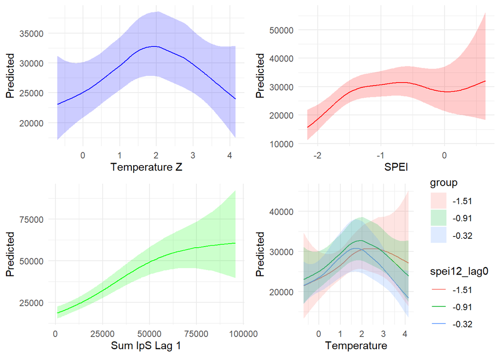

#### 2.1.4.2 Plot SPEI lag 1

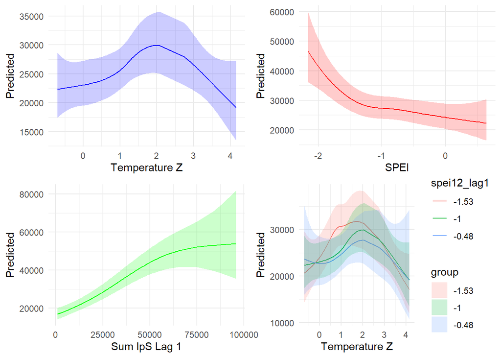

#### 2.1.4.3 Plot SPEI lag 2

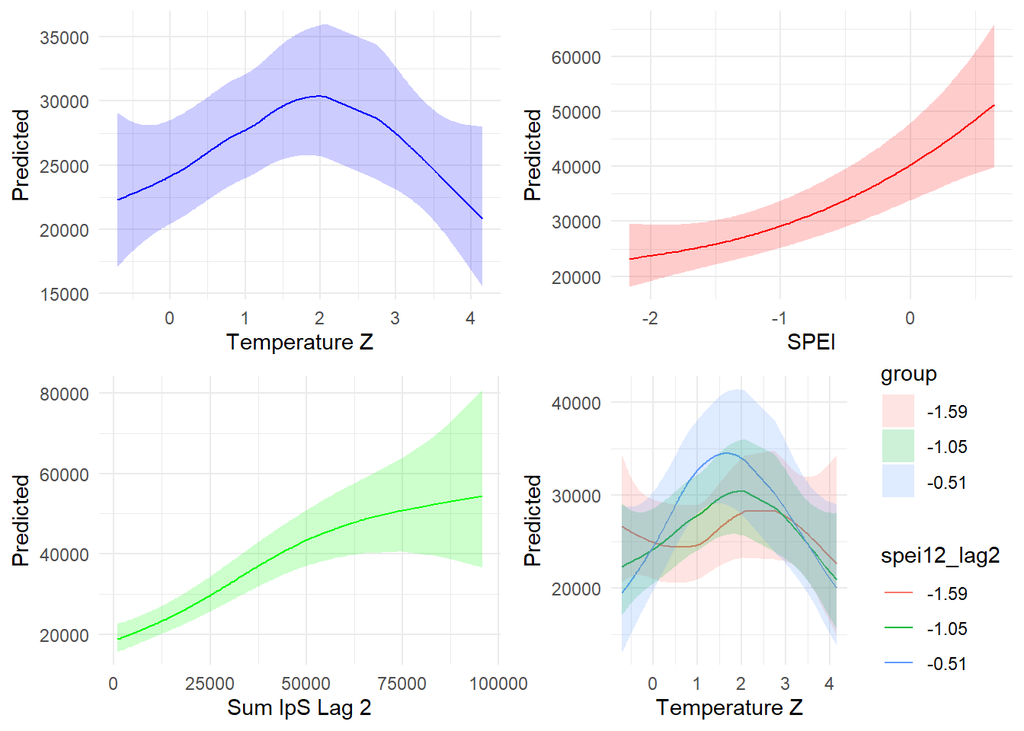

## 2.2 Beetle population level

### 2.2.1 Pop. level: Summary tmp_z

```
##
## Family: Tweedie
## Link function: log
##
## Formula:
## sum_ips ~ s(tmp_z_lag0, k = 5) + s(spei12_lag1, k = 8) + te(tmp_z_lag0,
##     spei12_lag1, k = 7) + s(sum_ips_lag1, k = 5) + s(x, y)
##
## Parametric coefficients:
##             Estimate Std. Error t value Pr(>|t|)
## (Intercept) 10.09076    0.02028   497.6   <2e-16 ***
## ---
## Signif. codes:  0 '***' 0.001 '**' 0.01 '*' 0.05 '.' 0.1 ' ' 1
##
## Approximate significance of smooth terms:
##                               edf Ref.df      F  p-value
## s(tmp_z_lag0)               1.000  1.000  1.807   0.1796
## s(spei12_lag1)              1.000  1.000  0.146   0.7030
## te(tmp_z_lag0,spei12_lag1)  8.057  8.057  4.787 1.19e-05 ***
## s(sum_ips_lag1)             2.593  2.593 59.326  < 2e-16 ***
## s(x,y)                     10.975 10.975  1.808   0.0575 .
## ---
## Signif. codes:  0 '***' 0.001 '**' 0.01 '*' 0.05 '.' 0.1 ' ' 1
##
## R-sq.(adj) =  0.427
##   Scale est. = 27.983    n = 444
```

### 2.2.2 Pop. level: Summary tmp

```
##
## Family: Tweedie
## Link function: log
##
## Formula:
## sum_ips ~ s(tmp_lag0, k = 5) + s(spei12_lag1, k = 8) + te(tmp_lag0,
##     spei12_lag1, k = 7) + s(sum_ips_lag1, k = 5) + s(x, y)
##
## Parametric coefficients:
##             Estimate Std. Error t value Pr(>|t|)
## (Intercept) 10.09337    0.02068   488.1   <2e-16 ***
## ---
## Signif. codes:  0 '***' 0.001 '**' 0.01 '*' 0.05 '.' 0.1 ' ' 1
##
## Approximate significance of smooth terms:
##                            edf Ref.df      F p-value
## s(tmp_lag0)              1.000  1.000  0.482 0.48786
## s(spei12_lag1)           4.243  4.243  4.191 0.00297 **
## te(tmp_lag0,spei12_lag1) 3.742  3.742  1.517 0.30344
## s(sum_ips_lag1)          2.626  2.626 62.511 < 2e-16 ***
## s(x,y)                   9.705  9.705  2.029 0.03512 *
## ---
## Signif. codes:  0 '***' 0.001 '**' 0.01 '*' 0.05 '.' 0.1 ' ' 1
##
## R-sq.(adj) =  0.408
##   Scale est. = 29.111    n = 444
```

### 2.2.3 Pop. level: AIC compare tmp vs tmp_z

```r
AIC(m.previous.tmp0_spei12_1,
    m.previous.tmp_z0_spei12_1)
```

```
##                            df      AIC
## m.previous.tmp0_spei12_1   14 583.5521
## m.previous.tmp_z0_spei12_1 14 570.1942
```

### 2.2.4 Pop. level: Temporal autocorrelation check

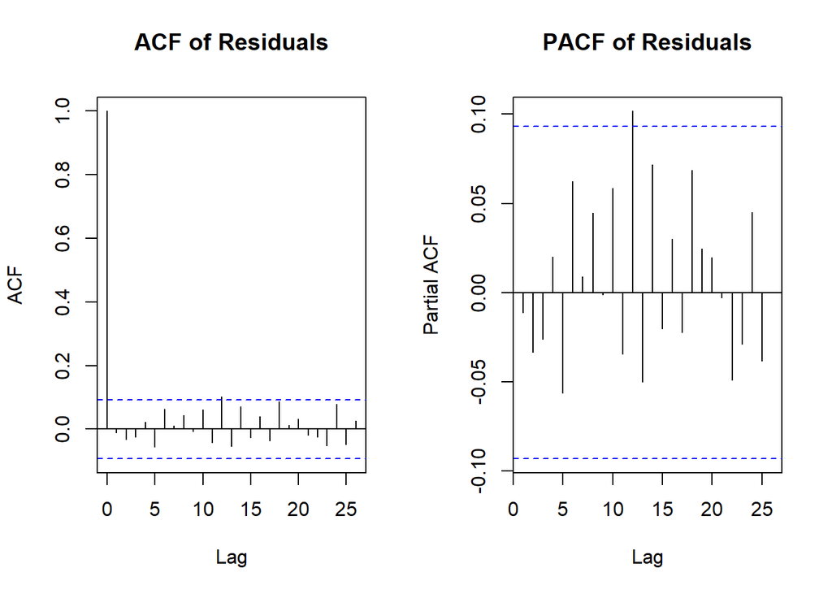

### 2.2.5 Pop. level: Plot tmp_z

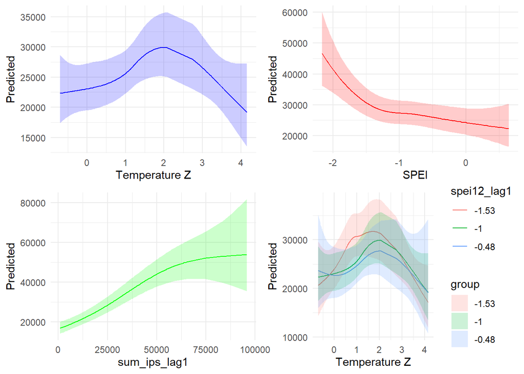

### 2.2.6 Pop. level: Plot tmp

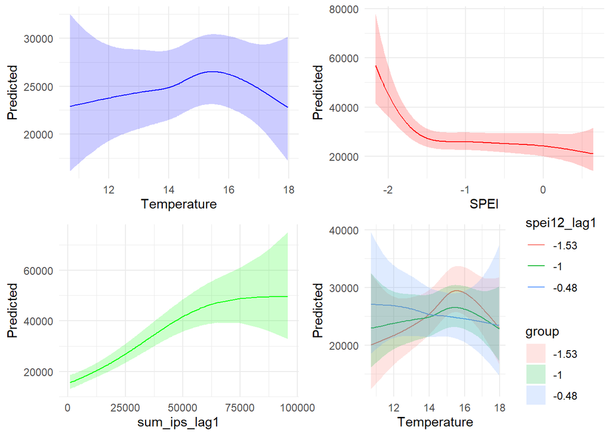